# Preliminary_results.Rmd

2024-12-01

PCA Analysis

## Title : Preliminary results of [Cooperation between arbuscular mycorrhizal fungi and plant growth-promoting bacteria and their effects on plant growth and soil quality](https://peerj.com/articles/13080/)

## Preamble :

This is the final project for the subject “Data Acquisition Analysis and Scientific Methods for Life Sciences” shorted as “Data” from the first course of the Master Plant Health at the Universitat Politècnica de València.

## Guidelines :

In this project the students chose a scientific article and redo all possible statistic analyses and graphics from it, trying different approaches to see if they can improve them. They will use the data included in the article and follow the Material and methods chapter as a guide.

### Introduction. Why your project is interesting? & What is known already about it?

We chose this scientific paper because we were interested in the knowledge we could gain about the relationship between plants & microorganisms *(here arbuscular mycorrhizal fungi (AMF) & plant growth-promoting bacteria (PGPB))*. A way to understand how the growth of plants & physico chemical properties of the soil are influenced by different treatments. Finaly, as “Almost 25% of the Earth’s biodiversity is composed of soil microorganisms (…)” (Fierer, 2017; Wagg et al., 2019; Whitman, Coleman & Wiebe, 1998), we thought we would acquire knowledge that we can later on, apply during our career.

### What we know already

**AMF** - present to 70% of the terrestrial plants *“Arbuscular mycorrhizal fungi (AMF), (…) maintain symbiotic relationships with over 70% of terrestrial plants and provide nutrients and water to plants in exchange for sugars through their arbuscules (…)”* (Schussler, Schwarzott & Walker, 2001; Wagg et al., 2019) and favorise the exchange of nutrients/sugars thanks to arbuscules. It enhances resilience of plants for drought, heavy metals & pathogens.

**PGPR** - include B (Bacillus spp…), contribute to the fixation of N, solubilisation of P, production of phytohormones & systemic resistance. *Bacillus spp. promotes plant growth by fixing N, solubilizing and mineralizing P and other nutrients, stimulating phytohormones, producing siderophores, inducing systemic resistance (ISR), and enhancing their tolerance to abiotic stresses* (Bonfante & Genre, 2010; Saxena et al., 2020). AMF & PGPR provide ecological solutions to improve health soil & plants productivity.

### Objectives and hypotheses

The objectives are to analyse if arbuscular mycorrhizal fungi* AMF* & plant growth-promoting rhizobacteria *PGRB* have any synergy effects on nutrients uptakes or plant growth to a more effective extent than for each microorganism studied alone.

The hypotheses are 1) AMF and PGPR could mutually symbiose and enhance the plant growth of Elymus nutans Griseb, & (2) the co-existence of AMF and PGPR could improve plant traits and soil quality better than their individual applications.

### Origin & structure of the data

It comes from the scientific article [Cooperation between arbuscular mycorrhizal fungi and plant growth-promoting bacteria and their effects on plant growth and soil quality](https://peerj.com/articles/13080/) by Yu L, Zhang H, Zhang W, Liu K, Liu M, Shao X. 2022.

plant_soil

| Group | Aboveground_Biomass | Belowground_Biomass | Total_Biomass | RootLength | RootSurfaceArea | RootAverageDiameter | Rvolume | Rootbranches | SIZE | R/S_ratio | HEIGHT | NH4+-N | NO3-N | Total_N | Total_C | Available_P | Total_P | ALP | UE | EC | PH | Plant_P | Plant_N | Plant_C | SRL |
| --- | --- | --- | --- | --- | --- | --- | --- | --- | --- | --- | --- | --- | --- | --- | --- | --- | --- | --- | --- | --- | --- | --- | --- | --- | --- |
| CK1 | 1.06 | 0.41 | 1.47 | 275.16 | 749.58 | 9.06 | 166.63 | 1646.67 | 0.41 | 0.39 | 23.58 | 5.58 | 161.20 | 0.22 | 3.54 | 2.43 | 0.14 | 1948.56 | 108.97 | 461 | 7.50 | 0.0688263 | 2.28 | 42.48 | 6.711220 |
| CK1 | 1.28 | 0.49 | 1.77 | 270.68 | 756.69 | 9.81 | 177.53 | 1062.00 | 0.65 | 0.38 | 26.08 | 9.83 | 142.40 | 0.20 | 3.41 | 2.16 | 0.45 | 2016.59 | 120.66 | 325 | 8.37 | 0.0693685 | 1.91 | 42.39 | 5.524082 |
| CK1 | 1.94 | 0.55 | 2.49 | 334.46 | 852.31 | 8.15 | 174.32 | 1201.67 | 0.62 | 0.29 | 30.23 | 6.87 | 86.61 | 0.19 | 3.22 | 2.15 | 0.53 | 2424.77 | 114.56 | 336 | 8.37 | 0.0730622 | 2.04 | 42.30 | 6.081091 |
| CK1 | 1.80 | 0.74 | 2.54 | 363.16 | 824.37 | 7.76 | 157.95 | 1506.33 | 0.63 | 0.41 | 27.50 | 6.97 | 107.99 | 0.22 | 3.51 | 2.56 | 0.54 | 2065.18 | 455.75 | 326 | 8.29 | 0.0181898 | 2.27 | 42.90 | 4.907568 |
| CK1 | 2.07 | 0.47 | 2.54 | 424.98 | 879.61 | 6.63 | 145.54 | 1632.33 | 0.47 | 0.23 | 31.52 | 7.67 | 161.40 | 0.26 | 3.40 | 2.17 | 0.50 | 2599.70 | 108.97 | 299 | 8.26 | 0.0758007 | 2.14 | 42.60 | 9.042128 |
| CK1 | 1.71 | 0.71 | 2.42 | 242.92 | 655.50 | 9.03 | 145.08 | 829.67 | 0.66 | 0.41 | 27.43 | 5.64 | 73.17 | 0.21 | 3.54 | 2.09 | 0.45 | 1851.37 | 132.86 | 247 | 8.44 | 0.0635255 | 1.94 | 43.17 | 3.421409 |
| A2 | 3.00 | 1.45 | 4.45 | 682.25 | 924.27 | 4.19 | 96.97 | 5640.67 | 0.82 | 0.48 | 37.10 | 8.35 | 182.70 | 0.26 | 3.49 | 2.23 | 0.34 | 3017.59 | 468.97 | 305 | 8.22 | 0.0175278 | 2.01 | 42.94 | 4.705172 |
| A2 | 3.00 | 1.50 | 4.50 | 682.09 | 842.44 | 4.10 | 87.15 | 6155.00 | 0.81 | 0.50 | 28.83 | 8.01 | 107.53 | 0.22 | 3.57 | 2.39 | 0.49 | 3007.88 | 392.69 | 267 | 8.42 | 0.0214418 | 1.85 | 43.41 | 4.547267 |
| A2 | 2.65 | 1.28 | 3.93 | 652.48 | 934.03 | 4.65 | 108.56 | 3510.67 | 0.80 | 0.48 | 33.17 | 8.42 | 83.75 | 0.21 | 3.40 | 2.05 | 0.46 | 2949.56 | 352.02 | 297 | 8.35 | 0.0237202 | 2.05 | 42.76 | 5.097500 |
| A2 | 2.71 | 1.08 | 3.79 | 573.57 | 922.97 | 5.55 | 128.53 | 2891.00 | 1.08 | 0.40 | 34.92 | 8.56 | 41.67 | 0.22 | 3.42 | 2.31 | 0.49 | 2142.93 | 360.15 | 236 | 8.43 | 0.0234069 | 1.98 | 43.03 | 5.310833 |
| A2 | 3.11 | 1.26 | 4.37 | 483.93 | 769.87 | 5.05 | 97.79 | 2097.67 | 0.87 | 0.40 | 35.17 | 7.76 | 107.37 | 0.23 | 3.38 | 2.21 | 0.53 | 2036.03 | 340.32 | 260 | 8.37 | 0.0245945 | 1.74 | 42.29 | 3.840714 |
| A2 | 2.38 | 1.09 | 3.47 | 590.92 | 908.33 | 4.93 | 112.62 | 4669.67 | 0.73 | 0.46 | 35.13 | 6.94 | 60.36 | 0.22 | 3.45 | 2.07 | 0.49 | 2570.54 | 442.02 | 248 | 8.49 | 0.0192073 | 2.22 | 43.33 | 5.421284 |
| B3 | 1.68 | 0.78 | 2.46 | 531.38 | 900.35 | 5.51 | 124.17 | 2033.00 | 0.66 | 0.46 | 30.50 | 10.77 | 71.90 | 0.20 | 3.57 | 1.97 | 0.50 | 2580.26 | 191.85 | 238 | 8.49 | 0.0442533 | 1.84 | 43.08 | 6.812564 |
| B3 | 1.78 | 0.98 | 2.76 | 568.62 | 908.13 | 5.10 | 116.96 | 3800.00 | 0.61 | 0.55 | 30.38 | 8.34 | 65.29 | 0.19 | 3.46 | 2.07 | 0.53 | 2191.52 | 314.39 | 254 | 8.47 | 0.0269411 | 1.84 | 43.13 | 5.802245 |
| B3 | 1.63 | 0.68 | 2.31 | 329.58 | 864.79 | 8.37 | 180.70 | 1205.33 | 0.76 | 0.41 | 27.43 | 8.00 | 79.29 | 0.19 | 3.39 | 2.17 | 0.48 | 1870.81 | 192.36 | 298 | 8.44 | 0.0438761 | 1.90 | 42.49 | 4.846765 |
| B3 | 1.66 | 0.65 | 2.31 | 331.15 | 788.11 | 7.79 | 154.79 | 2615.00 | 0.75 | 0.39 | 28.83 | 6.56 | 69.75 | 0.20 | 3.40 | 2.29 | 0.49 | 1997.15 | 126.25 | 257 | 8.47 | 0.0670891 | 2.17 | 42.16 | 5.094615 |
| B3 | 1.58 | 0.61 | 2.19 | 480.38 | 812.36 | 5.46 | 110.14 | 2111.00 | 0.62 | 0.39 | 26.50 | 7.38 | 92.70 | 0.20 | 3.42 | 2.15 | 0.40 | 2278.99 | 140.49 | 284 | 8.37 | 0.0595772 | 2.20 | 42.46 | 7.875082 |
| B3 | 1.69 | 0.78 | 2.47 | 439.80 | 1008.46 | 7.58 | 191.56 | 1828.00 | 0.76 | 0.46 | 30.83 | 6.74 | 110.28 | 0.21 | 3.39 | 2.11 | 0.50 | 2473.36 | 201.51 | 262 | 8.36 | 0.0414868 | 1.88 | 42.57 | 5.638462 |
| AB5 | 3.04 | 1.80 | 4.84 | 548.17 | 876.15 | 5.11 | 111.75 | 2795.67 | 0.84 | 0.59 | 39.58 | 8.36 | 48.84 | 0.21 | 3.50 | 2.39 | 0.46 | 3124.50 | 310.47 | 209 | 8.44 | 0.0271846 | 1.90 | 43.20 | 3.045389 |
| AB5 | 3.68 | 1.06 | 4.74 | 719.72 | 862.62 | 3.83 | 82.78 | 3750.33 | 0.91 | 0.29 | 39.50 | 8.24 | 34.00 | 0.22 | 3.50 | 2.43 | 0.49 | 3075.90 | 280.98 | 169 | 8.48 | 0.0301801 | 1.78 | 41.64 | 6.789811 |
| AB5 | 3.00 | 1.48 | 4.48 | 671.82 | 930.42 | 4.42 | 102.90 | 3251.00 | 0.91 | 0.49 | 34.30 | 7.80 | 59.25 | 0.21 | 3.47 | 2.19 | 0.47 | 2794.07 | 292.17 | 224 | 8.45 | 0.0289215 | 2.28 | 43.16 | 4.539324 |
| AB5 | 2.59 | 1.59 | 4.18 | 759.05 | 784.84 | 3.50 | 68.63 | 3742.33 | 0.83 | 0.61 | 32.42 | 10.74 | 58.11 | 0.20 | 3.51 | 5.83 | 0.47 | 3105.06 | 299.29 | 205 | 8.48 | 0.0283337 | 1.89 | 43.02 | 4.773899 |
| AB5 | 3.45 | 1.68 | 5.13 | 892.00 | 886.52 | 3.30 | 73.72 | 4783.33 | 0.87 | 0.49 | 40.42 | 8.96 | 33.30 | 0.22 | 3.38 | 2.15 | 0.48 | 2726.04 | 294.20 | 211 | 8.43 | 0.0286540 | 1.87 | 42.08 | 5.309524 |
| AB5 | 3.19 | 1.90 | 5.09 | 685.45 | 818.73 | 3.81 | 78.14 | 3451.33 | 0.79 | 0.60 | 36.92 | 11.32 | 42.53 | 0.22 | 3.45 | 2.15 | 0.45 | 2570.54 | 223.02 | 240 | 8.43 | 0.0377993 | 1.62 | 42.71 | 3.607632 |

*Details - CK : No occulation, A : Occulation of AMF only, B : Occulation of Bacillus only, AB : Occulation of Bacillus & AMF*

### What have we done? And what did we use to do it? Step by step, so anyone could do it again by reading this part.

- ANOVA (Analysis of Variance)

ANOVA (Analysis of Variance) is used to compare the means of multiple variances to determine if there are statistically significant differences between them. Here to compare the effects of AMF or PGPB treatment only, or combination of both treatments or none of them on soil content and plant growth. Also a way to analyze the impact of independent variables on a dependent variable & to test interactions between factors. Finaly done in order to reliably and efficiently compare the means of multiple groups while controlling for statistical errors.

- PCA (Principal Component Analysis)

PCA is a statistical technique used for dimensional reduction and data simplification. Transforming high-dimensional data into a smaller number of uncorrelated variables called *principal components*. These components capture the most important features of the original data.

**NB**: By keeping only the most important components, PCA simplifies the data without losing much information, which is particularly useful for tasks like pattern recognition, data visualization, and improving the performance of machine learning models.

- LDA (Linear Discriminant Analysis) It works by finding a linear combination of features that best separates multiple classes.

**NB**: Unlike PCA (*unsupervising and focusing on maximizing variance*) LDA aims to maximize the separation between different classes.

We plan to start with each variable analyses separately then ANOVA analyses we’ll combine these small results analyses with the knowledge acquire from the article chosen to define the larger scale multivariate analyses. These might be a relationship between soil nutrients/quality and plant size measurements (multiple roots measurements and above ground biomass).

# Results. Figures and tables with captions and description of what do they mean. Our only work.

# Corrected P values of ANOVA analysis of each variable

```
## [1] "ANOVA Results with Bonferroni Correction:"
```

```
##               Variable      P_Value Bonferroni_P
## 1  Aboveground_Biomass 1.720796e-08 4.301989e-07
## 2  Belowground_Biomass 4.246706e-08 1.061677e-06
## 3        Total_Biomass 1.466179e-10 3.665448e-09
## 4           RootLength 1.617969e-06 4.044922e-05
## 5      RootSurfaceArea 8.933732e-02 1.000000e+00
## 6  RootAverageDiameter 1.045000e-06 2.612500e-05
## 7              Rvolume 1.987182e-05 4.967955e-04
## 8         Rootbranches 2.484056e-04 6.210140e-03
## 9                 SIZE 4.571624e-05 1.142906e-03
## 10           R/S_ratio 2.100509e-02 5.251273e-01
## 11              HEIGHT 1.949411e-05 4.873528e-04
## 12              NH4+-N 8.381330e-02 1.000000e+00
## 13               NO3-N 5.681105e-03 1.420276e-01
## 14             Total_N 4.334691e-02 1.000000e+00
## 15             Total_C 9.020266e-01 1.000000e+00
## 16         Available_P 3.310077e-01 1.000000e+00
## 17             Total_P 7.903956e-01 1.000000e+00
## 18                 ALP 1.985803e-03 4.964509e-02
## 19                  UE 6.525022e-04 1.631255e-02
## 20                  EC 6.018803e-04 1.504701e-02
## 21                  PH 1.147915e-01 1.000000e+00
## 22             Plant_P 1.817950e-04 4.544876e-03
## 23             Plant_N 2.855678e-01 1.000000e+00
## 24             Plant_C 5.435702e-01 1.000000e+00
## 25                 SRL 1.875362e-01 1.000000e+00
```

# Showcasing all significant ANOVA analyses in boxplots

```
## PDF error: No display font for 'Symbol'
```

```
## PDF error: No display font for 'ArialUnicode'
```

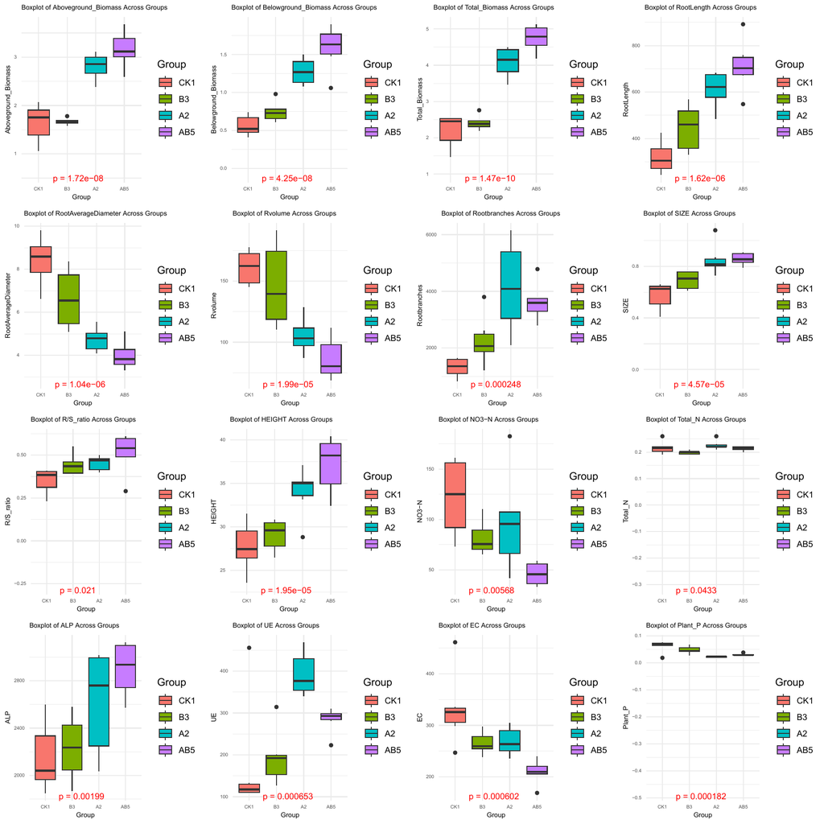

# Showcasing all ANOVA analysis with significant difference between AMF treatment and AMF + PGPB treatments

```
## [1] "Plots saved to Significant_ANOVA_fungivsbacteria.pdf"
```

[figure not shown]

*Details - NO3-N : Nitrate , UE : Soil urease enzyme , EC : Electrical conductivity , Plant P : Plant phosphorus*